# Activity Monitoring - Project 1

Fred Paredes

3/24/2019

## Project 1

It is now possible to collect a large amount of data about personal movement using activity monitoring devices such as a Fitbit, Nike Fuelband, or Jawbone Up. These type of devices are part of the “quantified self” movement – a group of enthusiasts who take measurements about themselves regularly to improve their health, to find patterns in their behavior, or because they are tech geeks. But these data remain under-utilized both because the raw data are hard to obtain and there is a lack of statistical methods and software for processing and interpreting the data.

The variables included in this dataset are:

- steps: Number of steps taking in a 5-minute interval (missing values are coded as **NA**)
- date: The date on which the measurement was taken in **YYYY-MM-DD** format
- interval: Identifier for the 5-minute interval in which measurement was taken

Dataset: [Activity monitoring data](https://d396qusza40orc.cloudfront.net/repdata%2Fdata%2Factivity.zip)

### Loading and processing the data

```r
data_rep <- read.csv("/Users/fredparedes/Documents/Data Science Course/Class/ReproducealbeResearchProject/activity.csv")

#convert factor to date type
data_rep$date <- as.Date(data_rep$date)

#get the mean per day
#mean_steps_per_day <- aggregate(data_rep2$steps, list(Date = data_rep2$date), FUN=mean)

# merge the activity with the descriptive label
#fixed_data_rep <- merge(mean_steps_per_day, data_rep, by.x = "date", by.y = "date", all = TRUE)


summary(data_rep)
```

```
##      steps             date               interval
##  Min.   :  0.00   Min.   :2012-10-01   Min.   :   0.0
##  1st Qu.:  0.00   1st Qu.:2012-10-16   1st Qu.: 588.8
##  Median :  0.00   Median :2012-10-31   Median :1177.5
##  Mean   : 37.38   Mean   :2012-10-31   Mean   :1177.5
##  3rd Qu.: 12.00   3rd Qu.:2012-11-15   3rd Qu.:1766.2
##  Max.   :806.00   Max.   :2012-11-30   Max.   :2355.0
##  NA's   :2304
```

### What is the histogrm of the total number of steps per day?

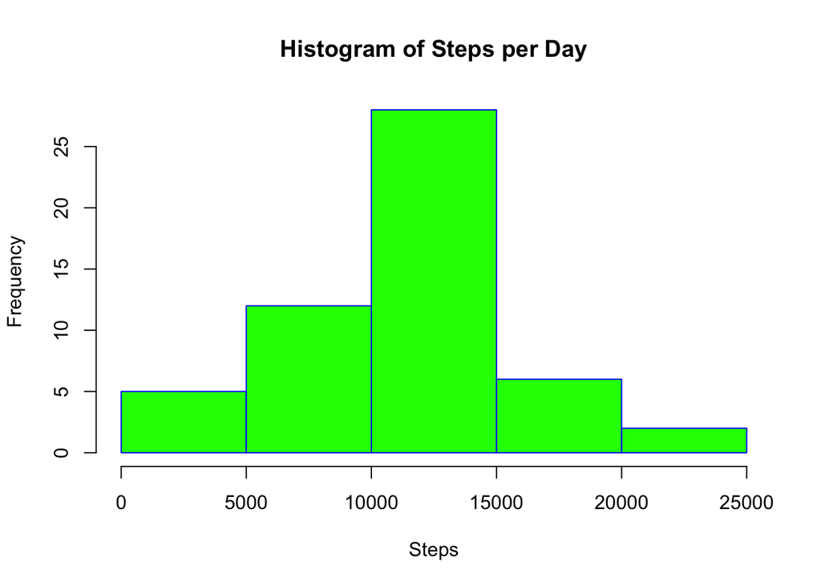

```r
#sum the number of steps per day
total_steps_per_day <- aggregate(data_rep$steps, list(Date = data_rep$date), FUN=sum)

steps_mean <- mean(total_steps_per_day$x, na.rm = TRUE)
steps_median <- median(total_steps_per_day$x, na.rm = TRUE)

hist(total_steps_per_day$x,
     main = "Histogram of Steps per Day",
     xlab = "Steps",
     border = "blue",
     col = "green")
```

[figure not shown]

```r
 median_steps_per_day <- aggregate(data_rep$steps, list(Interval = data_rep$interval), function(x) median(x, na.rm = TRUE))

plot(median_steps_per_day$Interval, median_steps_per_day$x, type = "l", xlab = "Steps", ylab = "Interval")
```

```r
max_steps <- median_steps_per_day[median_steps_per_day$x == max(median_steps_per_day$x), ]
```

**Interval with Maximum Steps:** 845, 60

### Inputing missing values

```r
# number of NAs
total_NA <- colSums(is.na(data_rep))

mean_steps_per_day <- aggregate(data_rep$steps, list(date = data_rep$date), function(x) mean(x, na.rm = TRUE))

# merge the data frames

names(mean_steps_per_day) <- c("date", "mean_steps")

merge_data_rep <- merge(data_rep, mean_steps_per_day)

# get rid of NaN for days with no values
merge_data_rep$mean_steps[merge_data_rep$mean_steps == "NaN"] <- 0

#replace NA values with mean value for that day

merge_data_rep$steps[is.na(merge_data_rep$steps)] <- merge_data_rep$mean_steps
```

[figure not shown]

```r
plot(merge_data_rep$interval, merge_data_rep$steps, type = "l", xlab = "Steps", ylab = "Interval")
```

**Total Number of NAs for columns Steps, Dates, Interval:** 2304, 0, 0

```r
#create new weekend column
merge_data_rep <- cbind(merge_data_rep, weekdays(as.Date(merge_data_rep$date)))

#rename columns
names(merge_data_rep) <- c("steps", "date", "interval", "mean_steps", "weekday")

#convert factor to character
merge_data_rep$weekday <- as.character(merge_data_rep$weekday)

#replace weekday names with either weekend or weekday
merge_data_rep$weekday[merge_data_rep$weekday == "Monday" | merge_data_rep$weekday == "Tuesday" | merge_data_rep$weekday == "Wednesday" | merge_data_rep$weekday == "Thursday" | merge_data_rep$weekday == "Friday"] <- "weekday"

merge_data_rep$weekday[merge_data_rep$weekday == "Saturday" | merge_data_rep$weekday == "Sunday"] <- "weekend"

#plot(merge_data_rep$interval, merge_data_rep$steps, type = "l", xlab = "Steps", ylab = "Interval")
#lines(merge_data_rep$weekdays == "weekday", type = "l", col = "red")

#Unable to finish two factor plot
```